# Candidate Cross-Match

Cross match PQLD candidates to the Legacy Survey DR10.

This notebook only runs in the NOIRLab Astro DataLab.

Legacy Survey overview: https://datalab.noirlab.edu/ls/ls.php

Tractor catalog schema: https://datalab.noirlab.edu/query.php?name=ls_dr10.tractor

For catalog units: https://www.legacysurvey.org/dr10/catalogs/https://www.legacysurvey.org/dr10/catalogs/

For cutouts: https://www.legacysurvey.org/viewer/cutout.jpg?ra=7.5334&dec=-43.4581&layer=ls-dr9&pixscale=0.06

## Import packages.

```python
import numpy as np
import matplotlib.pyplot as plt
import pandas as pd
from astropy.coordinates import SkyCoord
from dl.helpers.utils import convert
from __future__ import print_function
import getpass
from dl import authClient, queryClient, storeClient
```

## Retrieve data.

Read in the candidates and their coordinates.

```python
cand_id = np.loadtxt('PQLD_candidate_coordinates.dat', dtype='str', usecols=(0))
cand_ra = np.loadtxt('PQLD_candidate_coordinates.dat', dtype='float', usecols=(1))
cand_dec = np.loadtxt('PQLD_candidate_coordinates.dat', dtype='float', usecols=(2))
```

Set the rough, approximate field boundaries to use in the query.

ELAIS boundaries in RA and Dec.

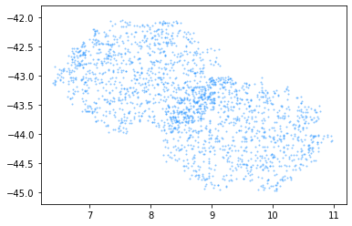

```python
tx = np.where((cand_ra > 5.0) & (cand_ra < 12.0) & (cand_dec > -46) & (cand_dec < -41))[0]
plt.plot(cand_ra[tx], cand_dec[tx], 'o', ms=2, alpha=0.5, mew=0, color='dodgerblue')
del tx

eb_ralo = 6.2
eb_rahi = 11.2
eb_delo = -45.2
eb_dehi = -41.8
plt.xlim([eb_ralo, eb_rahi])
plt.ylim([eb_delo, eb_dehi])

plt.show()
```

COSMOS boundaries in RA and Dec.

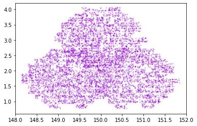

```python
tx = np.where((cand_ra > 147.0) & (cand_ra < 153.0) & (cand_dec > -0.25) & (cand_dec < 5))[0]
plt.plot(cand_ra[tx], cand_dec[tx], 'o', ms=2, alpha=0.5, mew=0, color='darkviolet')
del tx

cb_ralo = 148.0
cb_rahi = 152.0
cb_delo = 0.6
cb_dehi = 4.2
plt.xlim([cb_ralo, cb_rahi])
plt.ylim([cb_delo, cb_dehi])

plt.show()
```

Get your token in preparation for running queries.

```python
token = authClient.login ('melissagraham', getpass.getpass('Account password: '))
if not authClient.isValidToken (token):
    print ('Error: invalid user login (%s)' % token)
```

Set up to query the DR10 tractor table for objects in COSMOS or ELAIS.

```python
query = 'SELECT ra, dec, ref_id, ls_id, objid, ' + \
        'mag_g, mag_r, mag_i, ' + \
        'type, sersic, shape_e1, shape_e2, shape_r, ' + \
        'psfsize_g, psfsize_r, psfsize_i, ebv ' + \
        'FROM ls_dr10.tractor ' + \
        'WHERE (ra > '+str(cb_ralo)+' AND ra < '+str(cb_rahi)+' AND ' + \
        'dec > '+str(cb_delo)+' AND dec < '+str(cb_dehi)+') '\
        'OR (ra > '+str(eb_ralo)+' AND ra < '+str(eb_rahi)+' AND ' + \
        'dec > '+str(eb_delo)+' AND dec < '+str(eb_dehi)+')'
```

```python
print(query)
```

```
SELECT ra, dec, ref_id, ls_id, objid, mag_g, mag_r, mag_i, type, sersic, shape_e1, shape_e2, shape_r, psfsize_g, psfsize_r, psfsize_i, ebv FROM ls_dr10.tractor WHERE (ra > 148.0 AND ra < 152.0 AND dec > 0.6 AND dec < 4.2) OR (ra > 6.2 AND ra < 11.2 AND dec > -45.2 AND dec < -41.8)
```

```python
results = queryClient.query(token, sql=query)
```

Convert the retrieved results into a pandas dataframe.

```python
df = convert(results, 'pandas')
del results
```

Option to display pandas dataframe (automatically truncates).

```python
df
```

|  | ra | dec | ref_id | ls_id | objid | mag_g | mag_r | mag_i | type | sersic | shape_e1 | shape_e2 | shape_r | psfsize_g | psfsize_r | psfsize_i | ebv |
| --- | --- | --- | --- | --- | --- | --- | --- | --- | --- | --- | --- | --- | --- | --- | --- | --- | --- |
| 0 | 6.200076 | -44.828769 | 0 | 10995218900850328 | 5784 | 25.406033 | 25.514215 | 26.866148 | PSF | 0.0 | 0.000000 | 0.000000 | 0.000000 | 1.440332 | 1.113843 | 1.125045 | 0.006530 |
| 1 | 6.201691 | -44.829334 | 0 | 10995218900850377 | 5833 | 20.078783 | 19.196089 | 18.815495 | REX | 1.0 | 0.000000 | 0.000000 | 1.359949 | 1.440332 | 1.113843 | 1.125045 | 0.006545 |
| 2 | 6.201060 | -44.829002 | 0 | 10995218900850358 | 5814 | 24.707523 | 22.979002 | 21.869768 | PSF | 0.0 | 0.000000 | 0.000000 | 0.000000 | 1.440332 | 1.113843 | 1.125045 | 0.006535 |
| 3 | 6.203998 | -44.828872 | 0 | 10995218900850439 | 5895 | 25.845106 | 24.930586 | 24.987560 | PSF | 0.0 | 0.000000 | 0.000000 | 0.000000 | 1.440332 | 1.113843 | 1.125045 | 0.006546 |
| 4 | 6.211504 | -44.825932 | 0 | 10995218900850615 | 6071 | 24.233282 | 23.585741 | 22.648403 | REX | 1.0 | 0.000000 | 0.000000 | 0.299667 | 1.440332 | 1.113843 | 1.125045 | 0.006553 |
| ... | ... | ... | ... | ... | ... | ... | ... | ... | ... | ... | ... | ... | ... | ... | ... | ... | ... |
| 5609284 | 6.207986 | -44.808005 | 0 | 10995218900850531 | 5987 | 25.114712 | 23.710632 | 23.164661 | PSF | 0.0 | 0.000000 | 0.000000 | 0.000000 | 1.454011 | 1.108213 | 1.128227 | 0.006228 |
| 5609285 | 6.202675 | -44.807020 | 0 | 10995218900850406 | 5862 | 24.493582 | 24.121222 | 23.418850 | EXP | 1.0 | -0.404365 | -0.178699 | 0.787462 | 1.454011 | 1.108213 | 1.128227 | 0.006176 |
| 5609286 | 6.200874 | -44.806495 | 0 | 10995218900850354 | 5810 | 24.384703 | 23.483210 | 23.181862 | REX | 1.0 | 0.000000 | 0.000000 | 0.210898 | 1.454011 | 1.112234 | 1.128227 | 0.006155 |
| 5609287 | 6.200772 | -44.805964 | 0 | 10995218900850349 | 5805 | 24.873152 | 24.988148 | 25.768610 | REX | 1.0 | 0.000000 | 0.000000 | 0.514403 | 1.438553 | 1.112234 | 1.128227 | 0.006146 |
| 5609288 | 6.202538 | -44.805929 | 0 | 10995218900850401 | 5857 | 24.216183 | 23.884320 | 23.475489 | DEV | 4.0 | 0.007019 | 0.380743 | 0.717986 | 1.438553 | 1.112234 | 1.124079 | 0.006157 |

5609289 rows × 17 columns

Convert the pandas dataframe into numpy arrays for faster processing.

```python
dr10_ra = np.asarray(df['ra'], dtype='float')
dr10_dec = np.asarray(df['dec'], dtype='float')
dr10_ref_id = np.asarray(df['ref_id'], dtype='int')
dr10_ls_id = np.asarray(df['ls_id'], dtype='int')
dr10_objid = np.asarray(df['objid'], dtype='int')
dr10_mag_g = np.asarray(df['mag_g'], dtype='float')
dr10_mag_r = np.asarray(df['mag_r'], dtype='float')
dr10_mag_i = np.asarray(df['mag_i'], dtype='float')
dr10_type = np.asarray(df['type'], dtype='str')
dr10_sersic = np.asarray(df['sersic'], dtype='float')
dr10_shape_e1 = np.asarray(df['shape_e1'], dtype='float')
dr10_shape_e2 = np.asarray(df['shape_e2'], dtype='float')
dr10_shape_r = np.asarray(df['shape_r'], dtype='float')
dr10_psfsize_g = np.asarray(df['psfsize_g'], dtype='float')
dr10_psfsize_r = np.asarray(df['psfsize_r'], dtype='float')
dr10_psfsize_i = np.asarray(df['psfsize_i'], dtype='float')
dr10_ebv = np.asarray(df['ebv'], dtype='float')
del df
```

Confirm which of the identifiers are unique.

This shows that no, only the `ls_id` are unique.

```python
u_ref_id = np.unique(dr10_ref_id)
u_ls_id = np.unique(dr10_ls_id)
u_objid = np.unique(dr10_objid)
print(len(dr10_ra), len(u_ref_id), len(u_ls_id), len(u_objid))
del u_ref_id, u_ls_id, u_objid
```

```
5609289 99561 5609289 20802
```

Convert RA, Dec into astropy SkyCoord coordinates.

```python
cand_coords = SkyCoord(cand_ra, cand_dec, unit="deg")
dr10_coords = SkyCoord(dr10_ra, dr10_dec, unit="deg")
```

Create np array of links to candidate cutout in Legacy Survey viewer, and in Rob Knop's page.

These get used in verbose mode during the cross-matching, which helped with initial confirmations.

Otherwise their only use is to get written out to a file of handy links.

```python
tmp1 = 'https://www.legacysurvey.org/viewer/cutout.jpg?ra='
tmp2 = '&dec='
tmp3 = '&layer=ls-dr9&pixscale=0.06'

tmp_LSlink = []
tmp_DVlink = []

for c in range(len(cand_id)):
    tmp_LSlink.append(tmp1 + str(cand_ra[c]) + tmp2 + str(cand_dec[c]) + tmp3)
    tmp_DVlink.append('https://decat-webap.lbl.gov/decatview.py/cand/'+cand_id[c])

cand_LSlink = np.asarray(tmp_LSlink, dtype='str')
cand_DVlink = np.asarray(tmp_DVlink, dtype='str')
del tmp_LSlink, tmp_DVlink, tmp1, tmp2, tmp3
```

Plot the distributions of E(B-V) values for ELAIS and COSMOS.

The coefficiences are A / E(B-V) = 3.214, 2.165, 1.592 for DECam g r i filters.

- https://www.legacysurvey.org/dr10/catalogs/#galactic-extinction-coefficients

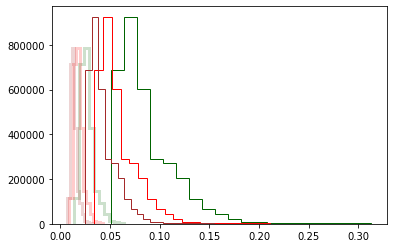

```python
cx = np.where((dr10_ra > cb_ralo) & (dr10_ra < cb_rahi) &
              (dr10_dec > cb_delo) & (dr10_dec < cb_dehi))[0]
ex = np.where((dr10_ra > eb_ralo) & (dr10_ra < eb_rahi) &
              (dr10_dec > eb_delo) & (dr10_dec < eb_dehi))[0]

# Plot the E(B-V) distributions
# plt.hist(dr10_ebv[cx], bins=20, histtype='step', color='darkviolet')
# plt.hist(dr10_ebv[ex], histtype='step', color='dodgerblue')

# Plot the A_f distributions to show max extinction
plt.hist(3.214 * dr10_ebv[cx], bins=20, histtype='step', lw=1, alpha=1, color='darkgreen')
plt.hist(3.214 * dr10_ebv[ex], histtype='step', lw=3, alpha=0.2, color='darkgreen')
plt.hist(2.165 * dr10_ebv[cx], bins=20, histtype='step', lw=1, alpha=1, color='red')
plt.hist(2.165 * dr10_ebv[ex], histtype='step', lw=3, alpha=0.2, color='red')
plt.hist(1.592 * dr10_ebv[cx], bins=20, histtype='step', lw=1, alpha=1, color='brown')
plt.hist(1.592 * dr10_ebv[ex], histtype='step', lw=3, alpha=0.2, color='brown')

plt.show()
```

## Cross match.

Find the nearest source.

If it is a star within a radius of 2 times the PSF, in r-band, that's the match.

If it is a galaxy within a radius of 5 times the half-light radius, then that is the match.

Flag instances where a star also had a galaxy match, and save the `ls_id`.

```python
# 0 if nothing within 72 arcsec; otherwise the number of nearby things
cand_region_pop = np.zeros(len(cand_id), dtype='int')

# -1 if no match; otherwise, the index in the dr10 array
cand_match_idx = np.zeros(len(cand_id), dtype='int') - 1

# -1 if no info; 0 if galaxy; 1 if star
cand_match_star = np.zeros(len(cand_id), dtype='int') - 1

# 1 if galaxy and potentially nuclear; 0 otherwise
cand_match_gnuc = np.zeros(len(cand_id), dtype='int')

# -1 if not matched; 0 if only matched to either star or galaxy; 1 if one or more of each
cand_match_flag = np.zeros(len(cand_id), dtype='int') - 1

# value of the offset in arcsec
cand_match_offset = np.zeros(len(cand_id), dtype='float')

for c, coord in enumerate(cand_coords):

    ralo = cand_ra[c] - 0.02
    rahi = cand_ra[c] + 0.02
    delo = cand_dec[c] - 0.02
    dehi = cand_dec[c] + 0.02
    tx = np.where((dr10_ra > ralo) & (dr10_ra < rahi) &
                  (dr10_dec > delo) & (dr10_dec < dehi))[0]
    del ralo, rahi, delo, dehi

    cand_region_pop[c] = len(tx)

    if len(tx) > 0:

        off_sky = coord.separation(dr10_coords[tx]).arcsec
        off_psf = off_sky / dr10_psfsize_r[tx]
        off_hlr = off_sky / dr10_shape_r[tx]

        ### identify all the potential star or galaxy matches
        sx = np.where((off_psf < 2) & (dr10_type[tx] == 'PSF'))[0]
        gx = np.where((off_hlr < 5) & (dr10_type[tx] != 'PSF'))[0]

        ### if there are some of each, flag as potential multiple matches
        if (len(sx) > 0) | (len(gx) > 0):
            cand_match_flag[c] = 0
        if (len(sx) > 0) & (len(gx) > 0):
            cand_match_flag[c] = 1

        del sx, gx

        ### sort by separation
        ix = np.argsort(off_sky)
        ### if the most nearby object is a star
        if dr10_type[tx[ix[0]]] == 'PSF':
            ### and that star is within 2x PSF, it's a match
            if off_psf[ix[0]] <= 2:
                cand_match_idx[c] = tx[ix[0]]
                cand_match_star[c] = 1
                cand_match_offset[c] = off_sky[ix[0]]
        del ix

        ### if not a star, check for a galaxy
        if cand_match_star[c] < 1:
            gx = np.where((off_hlr < 5) & (dr10_type[tx] != 'PSF'))[0]
            if len(gx) > 0:
                ### take the most nearby galaxy
                mx = np.argmin(off_sky[gx])
                cand_match_idx[c] = tx[gx[mx]]
                cand_match_star[c] = 0
                cand_match_offset[c] = off_sky[gx[mx]]
                if off_sky[gx[mx]] < dr10_psfsize_r[tx[gx[mx]]]:
                    cand_match_gnuc[c] = 1
                del mx
            del gx

    del tx
```

```python
tx = np.where(cand_match_idx >= 0)[0]
print(len(tx), ' out of ', len(cand_id))
del tx
```

```
9789  out of  9814
```

## Get photo-z from DR9.

Set up to query the DR9 tractor table and join to the photoz table.

Only interested in returning NON stars here, so we can cross-match with DR10 galaxies matched to candidates.

```python
query = 'SELECT dr9.ra, dr9.dec, pz.z_phot_mean, pz.z_phot_std, pz.z_spec ' + \
        'FROM ls_dr9.tractor_s AS dr9 ' + \
        'JOIN ls_dr9.photo_z AS pz ON pz.ls_id = dr9.ls_id ' + \
        'WHERE (ra > '+str(cb_ralo)+' AND ra < '+str(cb_rahi)+' AND ' + \
        'dec > '+str(cb_delo)+' AND dec < '+str(cb_dehi)+') '\
        'OR (ra > '+str(eb_ralo)+' AND ra < '+str(eb_rahi)+' AND ' + \
        'dec > '+str(eb_delo)+' AND dec < '+str(eb_dehi)+')'
```

```python
results = queryClient.query(token, sql=query)
df = convert(results, 'pandas')
del results
```

```python
# df
```

```python
dr9_ra = np.asarray(df['ra'], dtype='float')
dr9_dec = np.asarray(df['dec'], dtype='float')
dr9_zphot_mean = np.asarray(df['z_phot_mean'], dtype='float')
dr9_zphot_std = np.asarray(df['z_phot_std'], dtype='float')
dr9_zspec = np.asarray(df['z_spec'], dtype='float')
del df
```

```python
# plt.plot(dr9_ra, dr9_dec)
```

```python
# tx = np.where(dr9_zphot_mean >= 0.0)[0]
# print(len(tx), len(dr9_zphot_mean), len(dr9_zphot_mean)-len(tx))
# plt.hist(dr9_zphot_mean[tx], bins=20, histtype='step')
# plt.show()
# del tx
```

```python
# tx = np.where(dr9_zspec >= 0.0)[0]
# print(len(tx), len(dr9_zspec), len(dr9_zspec)-len(tx))
# plt.hist(dr9_zspec[tx], bins=20, histtype='step')
# plt.show()
# del tx
```

### Cross match PZ to candidates matched to DR10 galaxies

```python
cand_dr9_zphot_mean = np.zeros(len(cand_id), dtype='float') - 99.
cand_dr9_zphot_std = np.zeros(len(cand_id), dtype='float') - 99.
cand_dr9_zspec = np.zeros(len(cand_id), dtype='float') - 99.

for c in range(len(cand_id)):
    if cand_match_star[c] == 0:
        host_ra = dr10_ra[cand_match_idx[c]]
        host_dec = dr10_dec[cand_match_idx[c]]
        tx = np.where((np.abs(dr9_ra - host_ra) < 0.02) &
                      (np.abs(dr9_dec - host_dec) < 0.02))[0]
        if len(tx) > 0:
            coord_host = SkyCoord(host_ra, host_dec, unit="deg")
            coords_dr9 = SkyCoord(dr9_ra[tx], dr9_dec[tx], unit="deg")
            offsets = coord_host.separation(coords_dr9).arcsec
            ox = np.argmin(offsets)
            if offsets[ox] <= 2.0:
                cand_dr9_zphot_mean[c] = dr9_zphot_mean[tx[ox]]
                cand_dr9_zphot_std[c] = dr9_zphot_std[tx[ox]]
                cand_dr9_zspec[c] = dr9_zspec[tx[ox]]
            del ox, offsets, coords_dr9, coord_host
        del host_ra, host_dec, tx
```

```python
tx = np.where(cand_match_star == 0)[0]
ttx = np.where(cand_dr9_zphot_mean >= 0.0)[0]
tttx = np.where(cand_dr9_zspec >= 0.0)[0]
print(len(tx), len(ttx), len(tttx), len(ttx)/len(tx), len(tttx)/len(ttx))
del tx, ttx, tttx
```

```
551 510 210 0.925589836660617 0.4117647058823529
```

Only 551 matched to a galaxy, not a star.

Of them, 510 have a photo-z, 93%.

Of them, 210 have a spec-z, 41%.

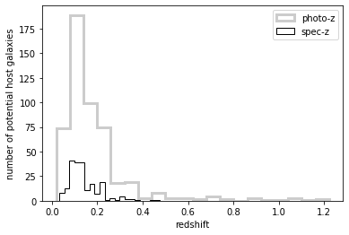

```python
ttx = np.where(cand_dr9_zphot_mean >= 0.0)[0]
tttx = np.where(cand_dr9_zspec >= 0.0)[0]
plt.hist(cand_dr9_zphot_mean[ttx], bins=20, histtype='step', lw=3, alpha=0.2, color='black', label='photo-z')
plt.hist(cand_dr9_zspec[tttx], bins=20, histtype='step', lw=1, alpha=1, color='black', label='spec-z')
plt.legend(loc='upper right')
plt.xlabel('redshift')
plt.ylabel('number of potential host galaxies')
plt.savefig('PQLD_hist_pz', bbox_inches='tight')
plt.show()
del ttx, tttx
```

## Write files.

Write the cross match information to file.

```python
fout = open('PQLD_candidate_xmatch_LSdr10.dat', 'w')
fout.write('# Matched DECam DDF candidates to the Legacy Survey DR10. \n')
fout.write('# Melissa Graham, October 2023 \n')
fout.write('# Legacy Surveys: https://datalab.noirlab.edu/ls/ls.php \n')
fout.write('# For more info on DR10 columns, units, etc: \n')
fout.write('#  - https://datalab.noirlab.edu/query.php?name=ls_dr10.tractor \n')
fout.write('#  - https://www.legacysurvey.org/dr10/catalogs/ \n')
fout.write('# \n')
fout.write('# Columns \n')
fout.write('#  0 : DECam DDF candidate identifier (string) \n')
fout.write('#  1 : DECam DDF candidate Right Ascension (deg; float) \n')
fout.write('#  2 : DECam DDF candidate Declination (deg; float) \n')
fout.write('#  3 : Number of DR10 sources within 0.02 deg radius (72") to attempt match (int) \n')
fout.write('#  4 : Flag: 1 if matched to a star; 0 if matched to a galaxy; -1 if unmatched (int) \n')
fout.write('#  5 : Flag: 1 if matched to the core of the galaxy; 0 otherwise (int) \n')
fout.write('#  6 : Flag: 1 if a star AND galaxy met constraints; 0 if one or the other; -1 if unmatched (int) \n')
fout.write('#  7 : Separation between candidate and matched DR10 object (arcsec; float) \n')
fout.write('#  8 : Matched LS DR10 object Right Ascension (deg; float) \n')
fout.write('#  9 : Matched LS DR10 object Declination (deg; float) \n')
fout.write('# 10 : Matched LS DR10 object MW E(B-V) value (mag; float) \n')
fout.write('# 11 : Matched LS DR10 object ls_id identifier (unique; long integer) \n')
fout.write('# 12 : Matched LS DR10 object g-band apparent magnitude (mag; float) \n')
fout.write('# 13 : Matched LS DR10 object r-band apparent magnitude (mag; float) \n')
fout.write('# 14 : Matched LS DR10 object i-band apparent magnitude (mag; float) \n')
fout.write('# 15 : Matched LS DR10 object type (str) \n')
fout.write('# 16 : Matched LS DR10 object sersic index (float) \n')
fout.write('# 17 : Matched LS DR10 object shape e1 (float) \n')
fout.write('# 18 : Matched LS DR10 object shape e2 (float) \n')
fout.write('# 19 : Matched LS DR10 object shape r (half-light radius; float) \n')
fout.write('# 20 : Matched LS DR10 object g-band psf size (arcsec; float) \n')
fout.write('# 21 : Matched LS DR10 object r-band psf size (arcsec; float) \n')
fout.write('# 22 : Matched LS DR10 object i-band psf size (arcsec; float) \n')
fout.write('# 23 : Matched LS DR9 object photoz mean (float) \n')
fout.write('# 24 : Matched LS DR9 object photoz std (float) \n')
fout.write('# 25 : Matched LS DR9 object specz (float) \n')
fout.write('# \n')
for c in range(len(cand_id)):
    i = cand_match_idx[c]
    if i >= 0:
        fout.write('%-10s %16.12f %16.12f '\
                   '%5i %2i %2i %2i '\
                   '%5.1f '\
                   '%10.6f %10.6f %7.3f %20i '\
                   '%7.3f %7.3f %7.3f '\
                   '%5s %6.2f '\
                   '%10.6f %10.6f %10.6f '\
                   '%10.6f %10.6f %10.6f '\
                   '%9.4f %9.4f %9.4f \n' %
                   (cand_id[c], cand_ra[c], cand_dec[c],
                    cand_region_pop[c], cand_match_star[c], cand_match_gnuc[c], cand_match_flag[c],
                    cand_match_offset[c],
                    dr10_ra[i], dr10_dec[i], dr10_ebv[i], dr10_ls_id[i],
                    dr10_mag_g[i], dr10_mag_r[i], dr10_mag_i[i],
                    dr10_type[i], dr10_sersic[i],
                    dr10_shape_e1[i], dr10_shape_e2[i], dr10_shape_r[i],
                    dr10_psfsize_g[i], dr10_psfsize_r[i], dr10_psfsize_i[i],
                    cand_dr9_zphot_mean[c], cand_dr9_zphot_std[c], cand_dr9_zspec[c]))
    else:
        fout.write('%-10s %16.12f %16.12f '\
                   '%5i %2i %2i %2i '\
                   '%5.1f '\
                   '%10.6f %10.6f %7.3f %20i '\
                   '%7.3f %7.3f %7.3f '\
                   '%5s %6.2f '\
                   '%10.6f %10.6f %10.6f '\
                   '%10.6f %10.6f %10.6f '\
                   '%9.4f %9.4f %9.4f \n' %
                   (cand_id[c], cand_ra[c], cand_dec[c],
                    cand_region_pop[c], cand_match_star[c], cand_match_gnuc[c], cand_match_flag[c],
                    -99.,
                    -99., -99., -99., -99,
                    -99., -99., -99.,
                    'xxx', -99.,
                    -99., -99., -99.,
                    -99., -99., -99.,
                    -99., -99., -99.))
fout.close()
```

```python
fout = open('PQLD_candidate_links.dat', 'w')
fout.write('# Links for DECam DDF candidates. \n')
fout.write('# Melissa Graham, October 2023 \n')
fout.write('# \n')
fout.write('# Columns \n')
fout.write('#  0 : DECam DDF candidate identifier (string) \n')
fout.write('#  1 : Link ot the Legacy Survey viewer cutout (string) \n')
fout.write('#  2 : Link to the DECam Viewer page (string) \n')
for c in range(len(cand_id)):
    fout.write(cand_id[c]+'  '+cand_LSlink[c]+'  '+cand_DVlink[c]+'   \n')
fout.close()
```

## Plot cross match results.

Type is either the best-fit point source (type="PSF"), round exponential galaxy model ("REX"), de Vaucouleurs model ("DEV"), exponential model ("EXP"), or a Sersic model ("SER").

Plot a few characteristics of the cross-match.

```python
print('cand_match_star')
values, counts = np.unique(cand_match_star, return_counts=True)
for v, vals in enumerate(values):
    print(vals, counts[v])
del values, counts
```

```
cand_match_star
-1 25
0 551
1 9238
```

```python
print('cand_match_gnuc')
values, counts = np.unique(cand_match_gnuc, return_counts=True)
for v, vals in enumerate(values):
    print(vals, counts[v])
del values, counts
```

```
cand_match_gnuc
0 9351
1 463
```

```python
print('type')
tx = np.where(cand_match_idx >= 0)[0]
values, counts = np.unique(dr10_type[cand_match_idx[tx]], return_counts=True)
for v, vals in enumerate(values):
    print(vals, counts[v])
print('total ', np.sum(counts), len(tx))
del values, counts, tx
```

```
type
DEV 21
EXP 60
PSF 9238
REX 77
SER 393
total  9789 9789
```

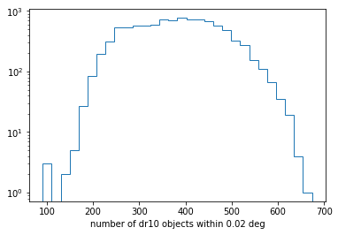

```python
plt.hist(cand_region_pop, bins=30, histtype='step', log=True)
plt.xlabel('number of dr10 objects within 0.02 deg')
plt.show()
```

```python
tx = np.where(cand_match_idx >= 0)[0]
sx = np.where(dr10_type[cand_match_idx[tx]] == 'PSF')[0]
gx = np.where(dr10_type[cand_match_idx[tx]] != 'PSF')[0]

print(len(tx), len(sx), len(gx))

del tx, sx, gx
```

```
9789 9238 551
```

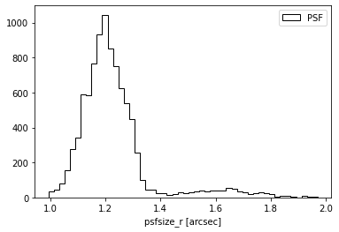

```python
tx = np.where(cand_match_idx >= 0)[0]
sx = np.where(dr10_type[cand_match_idx[tx]] == 'PSF')[0]

plt.hist(dr10_psfsize_r[cand_match_idx[tx[sx]]], bins=50, histtype='step', color='black', label='PSF')

plt.legend(loc='best')
plt.xlabel('psfsize_r [arcsec]')
plt.show()

del tx, sx
```

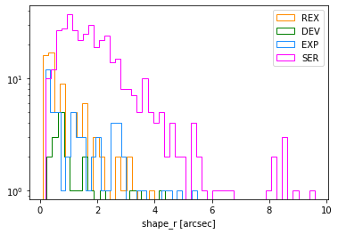

```python
tx = np.where(cand_match_idx >= 0)[0]
gx1 = np.where(dr10_type[cand_match_idx[tx]] == 'REX')[0]
gx2 = np.where(dr10_type[cand_match_idx[tx]] == 'DEV')[0]
gx3 = np.where(dr10_type[cand_match_idx[tx]] == 'EXP')[0]
gx4 = np.where(dr10_type[cand_match_idx[tx]] == 'SER')[0]

plt.hist(dr10_shape_r[cand_match_idx[tx[gx1]]], bins=20, histtype='step', log=True, color='darkorange', label='REX')
plt.hist(dr10_shape_r[cand_match_idx[tx[gx2]]], bins=20, histtype='step', log=True, color='green', label='DEV')
plt.hist(dr10_shape_r[cand_match_idx[tx[gx3]]], bins=30, histtype='step', log=True, color='dodgerblue', label='EXP')
plt.hist(dr10_shape_r[cand_match_idx[tx[gx4]]], bins=50, histtype='step', log=True, color='magenta', label='SER')

plt.legend(loc='best')
plt.xlabel('shape_r [arcsec]')
plt.show()

del tx, gx1, gx2, gx3, gx4
```

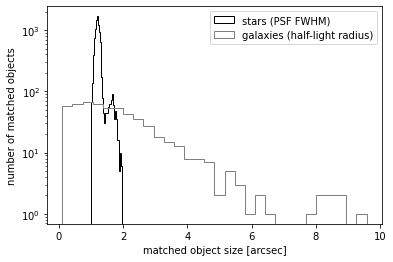

```python
tx = np.where(cand_match_idx >= 0)[0]
sx = np.where(dr10_type[cand_match_idx[tx]] == 'PSF')[0]
gx = np.where(dr10_type[cand_match_idx[tx]] != 'PSF')[0]

plt.hist(dr10_psfsize_r[cand_match_idx[tx[sx]]], bins=30, histtype='step',
         log=True, color='black', label='stars (PSF FWHM)')
plt.hist(dr10_shape_r[cand_match_idx[tx[gx]]], bins=30, histtype='step',
         log=True, color='grey', label='galaxies (half-light radius)')

plt.legend(loc='best')
plt.xlabel('matched object size [arcsec]')
plt.ylabel('number of matched objects')
plt.savefig('PQLD_hist_size', bbox_inches='tight')
plt.show()

del tx, sx, gx
```

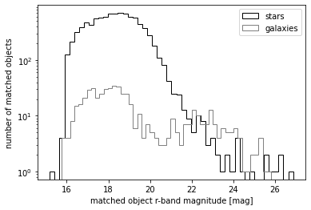

```python
tx = np.where(cand_match_idx >= 0)[0]
sx = np.where(dr10_type[cand_match_idx[tx]] == 'PSF')[0]
gx = np.where(dr10_type[cand_match_idx[tx]] != 'PSF')[0]

plt.hist(dr10_mag_r[cand_match_idx[tx[sx]]], bins=50, histtype='step',
         log=True, color='black', label='stars')
plt.hist(dr10_mag_r[cand_match_idx[tx[gx]]], bins=50, histtype='step',
         log=True, color='grey', label='galaxies')

plt.legend(loc='best')
plt.xlabel('matched object r-band magnitude [mag]')
plt.ylabel('number of matched objects')
plt.savefig('PQLD_hist_mag', bbox_inches='tight')
plt.show()

del tx, sx, gx
```

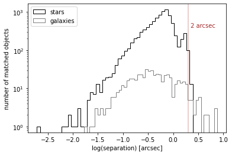

```python
sx = np.where(cand_match_star == 1)[0]
gx = np.where(cand_match_star == 0)[0]

plt.axvline(np.log10(2), alpha=0.3, color='brown')
plt.text(np.log10(2.2), 400, "2 arcsec", color='brown')

plt.hist(np.log10(cand_match_offset[sx]), bins=50, histtype='step',
         log=True, color='black', label='stars')
plt.hist(np.log10(cand_match_offset[gx]), bins=50, histtype='step',
         log=True, color='grey', label='galaxies')

plt.legend(loc='upper left')
plt.xlabel('log(separation) [arcsec]')
plt.ylabel('number of matched objects')
plt.savefig('PQLD_hist_sep', bbox_inches='tight')
plt.show()

del sx, gx
```

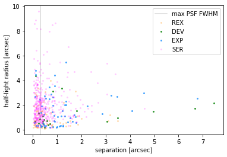

```python
tx = np.where(cand_match_idx >= 0)[0]
gx1 = np.where(dr10_type[cand_match_idx[tx]] == 'REX')[0]
gx2 = np.where(dr10_type[cand_match_idx[tx]] == 'DEV')[0]
gx3 = np.where(dr10_type[cand_match_idx[tx]] == 'EXP')[0]
gx4 = np.where(dr10_type[cand_match_idx[tx]] == 'SER')[0]

plt.axvline(np.log10(2), alpha=0.3, color='grey', label='max PSF FWHM')

plt.plot(cand_match_offset[tx[gx1]],
         dr10_shape_r[cand_match_idx[tx[gx1]]],
         'o', ms=3, alpha=0.3, mew=0, color='darkorange', label='REX')
plt.plot(cand_match_offset[tx[gx2]],
         dr10_shape_r[cand_match_idx[tx[gx2]]],
         'o', ms=3, alpha=0.8, mew=0, color='green', label='DEV')
plt.plot(cand_match_offset[tx[gx3]],
         dr10_shape_r[cand_match_idx[tx[gx3]]],
         'o', ms=3, alpha=0.8, mew=0, color='dodgerblue', label='EXP')
plt.plot(cand_match_offset[tx[gx4]],
         dr10_shape_r[cand_match_idx[tx[gx4]]],
         'o', ms=3, alpha=0.2, mew=0, color='magenta', label='SER')

plt.legend(loc='best')
plt.xlabel('separation [arcsec]')
plt.ylabel('half-light radius [arcsec]')
plt.show()

del tx, gx1, gx2, gx3, gx4
```

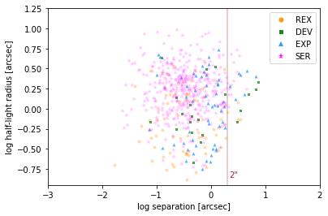

```python
tx = np.where(cand_match_idx >= 0)[0]
gx1 = np.where(dr10_type[cand_match_idx[tx]] == 'REX')[0]
gx2 = np.where(dr10_type[cand_match_idx[tx]] == 'DEV')[0]
gx3 = np.where(dr10_type[cand_match_idx[tx]] == 'EXP')[0]
gx4 = np.where(dr10_type[cand_match_idx[tx]] == 'SER')[0]

plt.axvline(np.log10(2), alpha=0.3, color='brown')
plt.text(np.log10(2.2), -0.85, '2"', color='brown')

plt.plot(np.log10(cand_match_offset[tx[gx1]]),
         np.log10(dr10_shape_r[cand_match_idx[tx[gx1]]]),
         'o', ms=4, alpha=0.3, mew=0, color='darkorange')
plt.plot(np.log10(cand_match_offset[tx[gx2]]),
         np.log10(dr10_shape_r[cand_match_idx[tx[gx2]]]),
         's', ms=3, alpha=0.7, mew=0, color='green')
plt.plot(np.log10(cand_match_offset[tx[gx3]]),
         np.log10(dr10_shape_r[cand_match_idx[tx[gx3]]]),
         '^', ms=4, alpha=0.7, mew=0, color='dodgerblue')
plt.plot(np.log10(cand_match_offset[tx[gx4]]),
         np.log10(dr10_shape_r[cand_match_idx[tx[gx4]]]),
         '*', ms=6, alpha=0.2, mew=0, color='magenta')

plt.plot(-99, -99, 'o', ms=6, alpha=0.9, mew=0, color='darkorange', label='REX')
plt.plot(-99, -99, 's', ms=5, alpha=0.9, mew=0, color='green', label='DEV')
plt.plot(-99, -99, '^', ms=6, alpha=0.9, mew=0, color='dodgerblue', label='EXP')
plt.plot(-99, -99, '*', ms=8, alpha=0.9, mew=0, color='magenta', label='SER')

plt.legend(loc='best')
plt.xlabel('log separation [arcsec]')
plt.ylabel('log half-light radius [arcsec]')
plt.xlim([-3, 2])
plt.ylim([-0.95, 1.25])
plt.savefig('PQLD_sep_vs_hlr', bbox_inches='tight')
plt.show()

del tx, gx1, gx2, gx3, gx4
```